# R Markdown Schedule (Example)

Olivia Beck

September 6, 2021

# Class Schedule

### STAT 184: Introduction to R Programmaing

This is my first time teaching STAT 184. I am passionate about R and the R community so I am very excited to be teach you all this semester! Have been coding in R for about 5 years and I use it nearly every day for both my classes and my research. I have written a few packages and even a web app all in R! There are lots of different approaches to R programming, but but we will be learning mostly from the `tidyverse` packages because I believe this to be a more unified and intuitive approach to the language (https://www.tidyverse.org/).

### SODA 502: Social Data Anlaytics Approaches and Issues

I am a duel PhD student in Statistics and Social Data Analytics. Penn State has a Social Data Analytics (SoDa) program in the College of Liberal Arts and offers duel degrees to PhD students in certain departments (https://soda.la.psu.edu/programs/graduate-program/). After I graduate I want to work in public policy analytics in government or a think tank, so SoDA is a perfect program for me. This class is a seminar where we meet once a week for 3 hours. In the first half of the class we listen to a speaker from the SoDA program talk about their research. In the second half of the class we learn how to implement statistical methods in social data research.

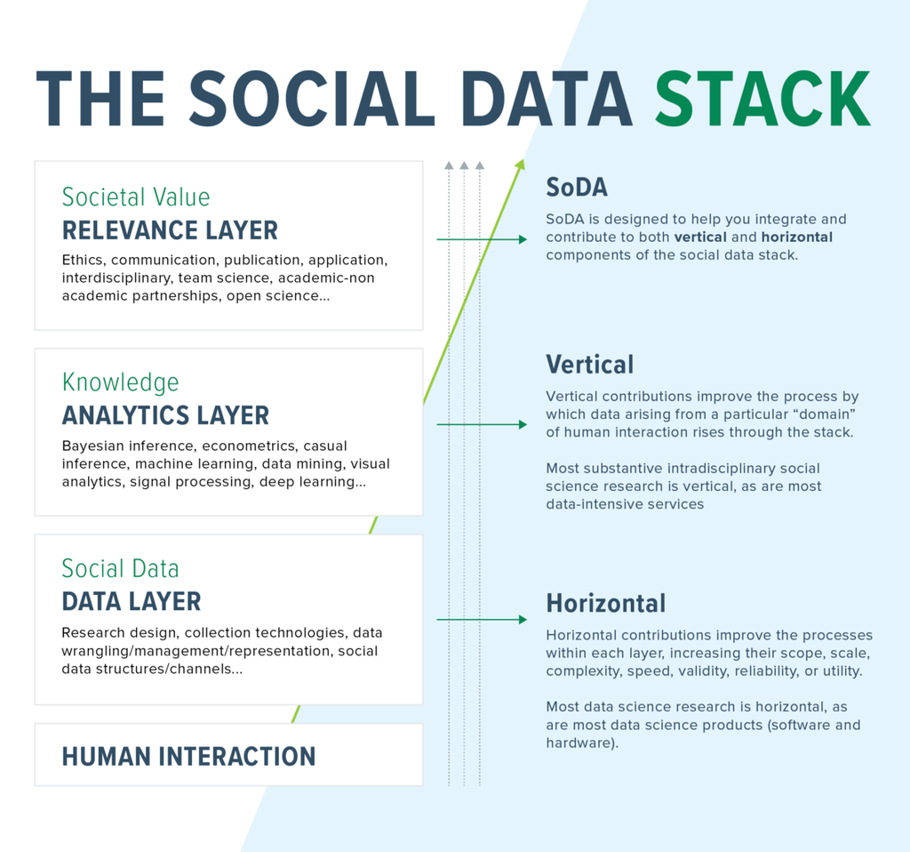

SoDA Stack (source: soda.la.psu.edu)

# Hobbies, Jobs, etc

### Research

My primary research interest is empirical likelihood with network data. Empirical likelihood is essentially (but not exactly) a fancy word for histogram. This is a non-parametric (model-free) method. My current project uses Jackknife and Bootstrap methods to identify influential actors in a network. One example I am using is the Trump World data set from [Buzzfeed](https://www.buzzfeednews.com/article/johntemplon/help-us-map-trumpworld). This data set displays how all of Trumps associates are associated with each other. I hope to submit this research for publication at the end of this academic year when I take my Comprehensive Exam.

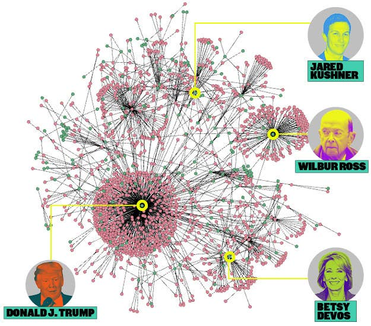

Trump World Network (source: Buzzfeed)

### Sci-fi / Fantasy Books

In my free time, I love to read science fiction and fantasy novels. I have always loved science fiction and I have just recently started reading fantasy novels during the pandemic. My all time favorite series is Dune. The first 6 Dune novels were written by Frank Herbert, and the remaining 18 novels were written by his son, Brian Herbert, and Kevin J. Anderson. I am currently reading book 17 of 24 titled *Sisterhood of Dune*. I am also reading book 2 of the Stormlight Archive by Brandon Sanderson. I think that Brandon Sanderson is one of the most prominent authors who is pushing the fantasy genre into the 21st century. [Click here](https://www.brandonsanderson.com) to learn more about Brandon Sanderson.

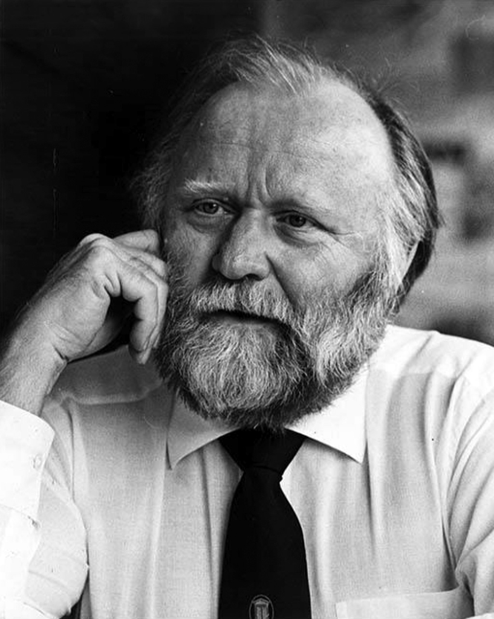

This is a picture of Frank Herbert in 1982.